# Homework 3

- Antonio Lomelí Ureña - Eddie Aguilar - Carolina Martínez - Enrique Tonatiuh Pérez Cortés

2024-02-07

#### *1 - A company’s cash position, measured in millions of dollars, follows a generalized. Wiener process with a drift rate of 0.5 per quarter and a variance rate of 4.0 per quarter. How high does the company’s initial cash position have to be for the company to have a less than 5% chance of a negative cash position by the end of 1 year?*

##### *1.1 Identify a and b for the generalized Wiener Process*

a = 0.5 per quarter

b = √4 = 2 per quarter

##### *1.2 Write the equation dx using a and b*

dx = 0.5dt + 2dW

##### *1.3 Write the equation dx when dt=4 (fourth quarters or one year)*

dx = 2 + 4ε Cambios por año

##### *1.4 Suppose that the initial cash position is Xo. Write the equation for X (not for dx)*

x = x0 + dx

x = x0 + 2 + 4ε Efectivo total en un año

##### *1.5 Find the expected value and variance of X*

E[x] = E[xo] + E[2] + E[4ε] = x0 + 2 + 0 = x0 + 2

Var[x] = Var[x0] + Var[2] + Var[4ε] = 0 +0+ 16(1) = 16

##### *1.6 Using 5) find P(X<0). Normalize and use normal standard distribution. If you are doing good, you should get a result that depends on Xo. Now your job is to find this value*

x~N(x0+2,16)

P(X<0) = P(z < (0-(x0+2)/√16) = P(z < (-x0-2)/4)

##### *1.7 Equalize de result on 6) to -1.65 (because you want less than 5% chance of a negative position). And solve for Xo.*

z0 = (-x0-2)/4 = -1.65 (este valor se busca en la tabla en caso de que no sea proporcionado)

-x0 -2 = -6.60

-x0 = -4.60

x0 = 4.60

##### *1.8 Use R to prove your answer. Simulate the equation X=Xo+adt+bdW using the Xo you found on 7) with dt=4 and a,b for the problem. Once you have at least 10000 simulations for X, calculate its mean and variance. Finally, use pnorm(0, mean(X), sd(X)) to find the probability that X (initial cash position) has to be less than zero.*

```r
set.seed(40)
n <- 100000
dt <- 4

a <- 0.5
b <- 2
x0 <- 4.6

epsilon <- rnorm(n, 0, 1)
dw <- epsilon*sqrt(dt)
dX <- a*dt + b*dw
X <- x0 + dX

mean(X)
```

```
## [1] 6.58714
```

```r
sd(X)^2
```

```
## [1] 16.05431
```

```r
1  - pnorm(q=0, mean=mean(X), sd=sd(X), lower.tail=FALSE)
```

```
## [1] 0.05008838
```

#### *2 - A company’s cash position, measured in millions of dollars, follows a generalized Wiener process with a drift rate of 0.1 per month and a variance rate of 0.16 per month. The initial cash position is 2.0.*

a = 0.1 per month

b = √.16 = 0.4 per month

x0 = 2

dx = 0.1dt + 0.4dW

dx = 0.1dt + 0.4ε√dt Cambios por mes

x = x0 + dx

Var[x] = Var[2] + Var[0.12] + Var[0.4√12ε ] = 0 + 0 + (0.16)(12) = 1.92

##### *2.1 What are the probability distributions of the cash position after 1 month, 6 months, and 1 year?*

- *A un mes*

$$X = 2 + 0.1dt + 0.4\epsilon\sqrt{dt} = 2 +
0.1(1) + 0.44\sqrt{1}\epsilon$$
$$X
= 2.1 + 0.4\epsilon$$
$$E[X] =
E[2.1] + 0.4E[\epsilon] = 2.1$$
$$Var[X] = Var[2.1] + Var[0.4\epsilon] = 0.16Var[\epsilon] = 0.16$$

Entonces $N ~ (2.1,0.16)$

- *A seis meses*

$$X = 2 + 0.1dt + 0.4\epsilon\sqrt{dt} = 2 +
0.1(6) + 0.4\sqrt{6}\epsilon$$
$$X =
2.6 + 0.4\sqrt{6}\epsilon$$
$$E[X] =
E[2.6] + 0.4\sqrt{6} E[\epsilon] = 2.6$$
$$Var[X] = Var[2.6] + Var[0.4\sqrt{6}\epsilon] =
0.96Var[\epsilon] = 0.96$$

Entonces, cuando pasen seis meses la variable X tendrá una distribución $N ~ (2.6,\sqrt{0.96})$

- *A un año*

$$X = 2 + 0.1dt + 0.4\epsilon\sqrt{dt} = 2 +
0.1(12) + 0.4\sqrt{12}\epsilon$$
$$X
= 3.2 + 0.4\sqrt{12}\epsilon$$
$$E[X] = E[3.2] + 0.4\sqrt{12} E[\epsilon] = E[3.2] + 0.4\sqrt{12}*0 = 3.2$$
$$Var[X] = Var[2.6] +
Var[0.4\sqrt{12}\epsilon] = 192Var[\epsilon] = 1.92$$

Entonces, a un año X tendrá una distribución $N ~ (3.2,\sqrt{1.92})$

##### 2.2 What are the probabilities of a negative cash position at the end of 6 months and 1 year?

*At the end of six months*

Finding the value of Z in Excel $P(X<0) = 0.003982$

*At the end of one year*

Finding the value of Z in Excel $P(X<0) = 0.0104$

```r
n <- 100000
dt <- 40

a <- 0.1
b <- 0.4
x0 <- 2

epsilon <- rnorm(n, 0, 1)
dw <- epsilon*sqrt(dt)
dX <- a*dt + b*dw
X <- x0 + dX

mean(X)
```

```
## [1] 6.010023
```

```r
sd(X)^2
```

```
## [1] 6.437152
```

```r
# Simular para graficar los dias
n <- 2000
dt <- 1
dias <- 40
a <- 0.1
b <- 0.4

X0 <- 2
X <- matrix(0, nrow=n, ncol=dias)

X[,1] <- X0

for (j in 1:n) {
epsilon <- rnorm(n,mean = 0, sd = 1)
dw <- epsilon*sqrt(dt)
dX <- a*dt + b*dw

for (t in 2:dias) {
    X[j,t] <- X[j,t-1] + dX[t]
}}

mean(X[,40])
```

```
## [1] 5.889985
```

```r
sd(X[,40])^2
```

```
## [1] 6.166272
```

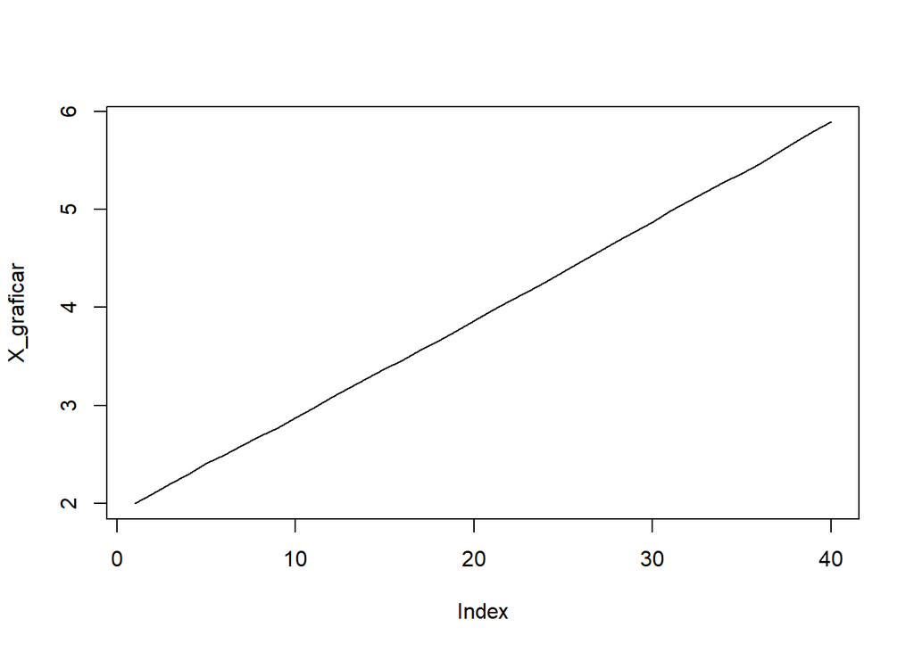

```r
# Graficar
X_graficar = colMeans(X)

plot(X_graficar, type="l")
```

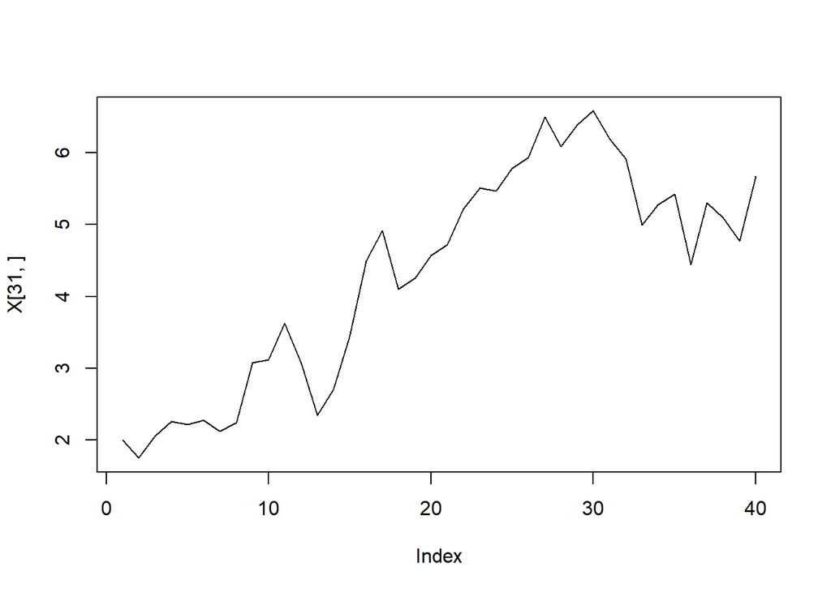

```r
plot(X[31,], type='l')
```